# Solow Model

## Jesse Saechao

The purpose of this project was to use total factor productivity (TFP) values to calculate Solow residuals to compare them with the natural growth factors of a given country.

Although using a class as opposed to a function wasn't the most efficient method in regards to calculating Solow residuals, assignment restrictions required the use of a class.

## Imports

```python
import pandas as pd
import pandas_datareader as pdr
import statsmodels.api as sm
import datetime
import scipy.stats
import numpy as np
import requests
from sympy import *
from fredapi import Fred
fred = Fred(api_key = 'key.txt')
import matplotlib.pyplot as plt
plt.rcParams["figure.figsize"] = [10,8]
```

```python
# Requires pwt100.xlsx
filename = "pwt100.xlsx"
try:
   open(filename, 'r')
   print(filename + " has been found")
except OSError as e:
   print(filename + " is not available, make sure it is in the working directory.")
```

```
pwt100.xlsx has been found
```

## The class

For the class to function properly, these methods must be called:

- get_data
- preliminary
- tfp_regression
- compute_parameters

These methods have already been programmed to run in the cells of this notebook but the previous message serves as a forewarning.

```python
class Solow_class: # country is an ISO code and should be a string
                   # Year is an integer value from 1954 - 2019

    def __init__ (self, country, year):
        self.country = country
        self.year = year
        self.df_country = None # Main Dataframe with ALL Country Data
        self.dict = {} # dictionary with calculations and subsetted data
        # Workable Variables
        # These variables are used for comparing data
        self.rho = 0.0
        self.k = None # used to pass through capital value for given year
        self.yhat = None # used to predict data
        self.a = None
        self.tfp = None

    def get_data(self):
        '''
        Retrieves data from pwt100.xlsx and creates workable dataframes
        '''
        # retrieving data and making it more manageable
        xls = pd.read_excel('pwt100.xlsx', 'Data')
        self.df_country = xls[xls["countrycode"] == self.country]
        self.df_country.index = self.df_country['year'] # makes indexing much easier!
        self.df_country = self.df_country.dropna(subset = 'rtfpna')

    def preliminary(self):
        self.dict['y'] = self.df_country['rgdpna'] / self.df_country['emp'] # gdp per cap
        self.dict['k'] = self.df_country['rnna'] / self.df_country['emp']
        self.dict['tfp'] = self.df_country['rtfpna']
        self.k = self.dict['k'].loc[self.year] # creating k value

    def tfp_regression(self):
        lhv = np.log(self.df_country['rtfpna'])
        rhv = np.arange(len(lhv))
        rhv = sm.add_constant(rhv)

        lr = sm.OLS(lhv, rhv).fit()
        self.dict['resids'] = lhv - lr.predict(rhv)
        #self.dict['n'] = np.exp(lr.params[0])
        #self.dict['g'] = np.exp(lr.params[1])
        print(lr.summary())

    def compute_parameters(self):
        self.dict['delta'] = self.df_country['delta'].mean()
        self.dict['s'] =  self.df_country['csh_i'].mean()
        self.dict['a_k'] = 1 - self.df_country['labsh'].mean()
        self.dict['n'] = (np.log(self.df_country.loc[2019, 'emp']) - np.log(self.df_country.loc[1954, 'emp'])) / len(self.df_country)
        self.dict['g'] = (np.log(self.df_country.loc[2019, 'rtfpna']) - np.log(self.df_country.loc[1954, 'rtfpna'])) / len(self.df_country)
        self.dict['yhat'] = self.intensive(self.k, A = 1)
        self.dict['A'] = self.dict['y'].loc[2017] / self.dict['yhat']
        return pd.DataFrame(self.dict)

    def intensive(self, k, A):
        if self.rho == 0:
            f = lambda k: A * k ** self.dict['a_k']
        else:
            f = lambda k: A * ((self.dict['a_k'] * k ** self.rho) + (1 - self.dict['a_k'])) ** (1/self.rho)
        return f(k)

    def compare_data(self): # compares actual data with estimates
        self.tfp = self.df_country['rtfpna'].dropna()
        self.a = 1-self.df_country['labsh']
        self.yhat = (self.tfp * self.dict['k'] ** self.a).dropna()
        self.yhat = self.dict['A']*self.yhat
        plt.title('Per capita GDP and Model prediction')
        plt.ylabel('logarithm of 2017 US $ per worker')
        np.log(self.dict['y']).plot(color = 'steelblue')
        np.log(self.yhat).plot(color='red')
        plt.legend(['Data','Prediction'])
        plt.show()

    def solow(self, k):
                sfk = self.dict['n'] + self.dict['g'] + (self.dict['n'] * self.dict['g']) + self.dict['delta']
                thinning = (k * sfk)
                thickening = self.dict['s'] * self.intensive(self.k , self.dict['A'])
                return thickening - thinning

    def my_bisection(self, a, b, tol):
        if np.sign(self.solow(a)) == np.sign(self.solow(b)):
               raise Exception("The scalars a and b do not bound a root")

        m = (a + b) / 2

        if np.abs(self.solow(m)) < tol:
            return m
        elif np.sign(self.solow(a)) == np.sign(self.solow(m)):
            return self.my_bisection(a = m, b = b, tol = tol)
        elif np.sign(self.solow(b)) == np.sign(self.solow(m)):
            return self.my_bisection(a = a, b = m, tol = tol)

    def steady_state(self):
        kbar = self.my_bisection(a = 0.1, b = 1000000, tol = 1e-6)
        print('The steady-state capital stock per efficiency unit of worker is:\n',np.around(kbar, 0))
        ybar = self.intensive(kbar, self.dict['A'])
        print('Steady-state GDP per efficiency unit of worker is:\n',np.around(ybar, 0))

        x = symbols('x')
        rbar = diff(self.intensive(x, self.dict['A'])).subs(x, kbar)  #This is tricky syntax
        print("The steady-state rentals rate is:\n", np.around(float(rbar),3))
        print("In steady-state, capital's share is:\n", np.around(float(rbar)*kbar/ybar,2))

        # half life
        b = ( 1 - self.dict['delta'] + self.dict['s'] * float(rbar)) / (1 + self.dict['n'] + self.dict['g'] + self.dict['n'] * self.dict['g'])
        print("b is", np.around(b,3))
        half_life = -np.log(2)/np.log(b)
        print("The half-life of the system is:\n",np.around(half_life,1))

    def compare_usa(self): # compares USA data with a given country
        var_names = ['GDPC1']
        start = datetime.datetime (1954, 1, 1)
        end = datetime.datetime (2019, 10, 1)
        df_GDP = pdr.DataReader(var_names, 'fred', start,end)
        Y_cycle, Y_trend = sm.tsa.filters.hpfilter(np.log(df_GDP['GDPC1']), 1600)
        df_GDP["Y_Cycle"] = Y_cycle
        x = df_GDP.groupby(df_GDP.index.year)['Y_Cycle'].mean()
        plt.title('Solow residuals')
        plt.ylabel('Percentage deviations')
        x.plot(color = "red")
        resids = self.dict['resids']
        resids.plot(color = 'steelblue')
        plt.legend(['USA',self.country])
        plt.show()
        r = np.corrcoef(x, resids)[0,1]
        print('The correlation coefficient is:\n',r)
        n = len(x)
        tstat = r*np.sqrt(n-2)/np.sqrt(1-r**2)
        tstat
        p_value = scipy.stats.t.sf(abs(tstat), df = n-2)
        print('Its p-value is:\n',p_value)
```

## Choose what values to pass in the class and creating data

The class takes two values:

- An string that is an ISO code
- An integer that represents a year from 1954 - 2019

```python
test = Solow_class('USA', 2017) # country, year
test.get_data()
test.preliminary()
test.compute_parameters()
```

| year | y | k | tfp | delta | s | a_k | n | g | yhat | A |
| --- | --- | --- | --- | --- | --- | --- | --- | --- | --- | --- |
| 1954 | 44021.629118 | 184053.396405 | 0.650097 | 0.035958 | 0.245609 | 0.381945 | 0.013348 | 0.006778 | 142.152527 | 888.840038 |
| 1955 | 45830.338713 | 185375.077331 | 0.671131 | 0.035958 | 0.245609 | 0.381945 | 0.013348 | 0.006778 | 142.152527 | 888.840038 |
| 1956 | 45702.003761 | 187282.735806 | 0.667314 | 0.035958 | 0.245609 | 0.381945 | 0.013348 | 0.006778 | 142.152527 | 888.840038 |
| 1957 | 46436.679020 | 192475.536526 | 0.674576 | 0.035958 | 0.245609 | 0.381945 | 0.013348 | 0.006778 | 142.152527 | 888.840038 |
| 1958 | 46940.669850 | 201632.138348 | 0.675796 | 0.035958 | 0.245609 | 0.381945 | 0.013348 | 0.006778 | 142.152527 | 888.840038 |
| ... | ... | ... | ... | ... | ... | ... | ... | ... | ... | ... |
| 2015 | 124967.378936 | 433001.508871 | 0.992851 | 0.035958 | 0.245609 | 0.381945 | 0.013348 | 0.006778 | 142.152527 | 888.840038 |
| 2016 | 125314.168512 | 432909.299022 | 0.993718 | 0.035958 | 0.245609 | 0.381945 | 0.013348 | 0.006778 | 142.152527 | 888.840038 |
| 2017 | 126350.857835 | 432803.394168 | 1.000000 | 0.035958 | 0.245609 | 0.381945 | 0.013348 | 0.006778 | 142.152527 | 888.840038 |
| 2018 | 128472.723459 | 434063.889588 | 1.008182 | 0.035958 | 0.245609 | 0.381945 | 0.013348 | 0.006778 | 142.152527 | 888.840038 |
| 2019 | 129903.001402 | 436255.479472 | 1.016862 | 0.035958 | 0.245609 | 0.381945 | 0.013348 | 0.006778 | 142.152527 | 888.840038 |

66 rows × 10 columns

## Comparing the data

The method, compare_data, creates a comparison between predicted values and actual data.

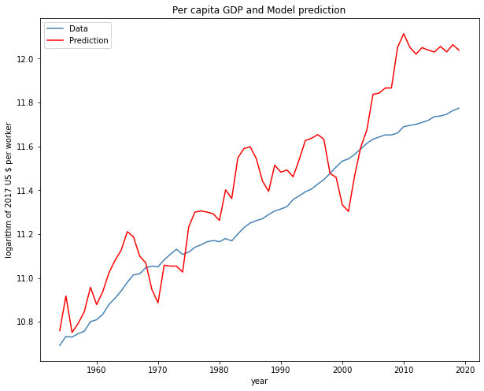

```python
test.compare_data()
```

## Regression on total factor productivity

```python
test.tfp_regression()
```

```
                            OLS Regression Results
==============================================================================
Dep. Variable:                 rtfpna   R-squared:                       0.970
Model:                            OLS   Adj. R-squared:                  0.969
Method:                 Least Squares   F-statistic:                     2054.
Date:                Wed, 08 Mar 2023   Prob (F-statistic):           2.34e-50
Time:                        13:23:53   Log-Likelihood:                 161.45
No. Observations:                  66   AIC:                            -318.9
Df Residuals:                      64   BIC:                            -314.5
Df Model:                           1
Covariance Type:            nonrobust
==============================================================================
                 coef    std err          t      P>|t|      [0.025      0.975]
------------------------------------------------------------------------------
const         -0.3836      0.005    -74.047      0.000      -0.394      -0.373
x1             0.0062      0.000     45.325      0.000       0.006       0.007
==============================================================================
Omnibus:                        0.937   Durbin-Watson:                   0.257
Prob(Omnibus):                  0.626   Jarque-Bera (JB):                0.989
Skew:                           0.177   Prob(JB):                        0.610
Kurtosis:                       2.516   Cond. No.                         74.5
==============================================================================

Notes:
[1] Standard Errors assume that the covariance matrix of the errors is correctly specified.
```

## Steady State

The steady_state method calculates roots using the intensive(), my_bisection(), and solow() method. \ It outputs:

- steady state capital
- steady state gdp
- steady state rental rate
- steady state capital share
- the half life of the system

```python
test.steady_state()
```

```
The steady-state capital stock per efficiency unit of worker is:
 552438.0
Steady-state GDP per efficiency unit of worker is:
 138695.0
The steady-state rentals rate is:
 0.096
In steady-state, capital's share is:
 0.38
b is 0.968
The half-life of the system is:
 21.3
```

## Now, let's run the comparison for a couple of different countries

### Comparison for DEU

```
                            OLS Regression Results
==============================================================================
Dep. Variable:                 rtfpna   R-squared:                       0.938
Model:                            OLS   Adj. R-squared:                  0.937
Method:                 Least Squares   F-statistic:                     966.4
Date:                Wed, 08 Mar 2023   Prob (F-statistic):           2.47e-40
Time:                        13:23:58   Log-Likelihood:                 84.862
No. Observations:                  66   AIC:                            -165.7
Df Residuals:                      64   BIC:                            -161.3
Df Model:                           1
Covariance Type:            nonrobust
==============================================================================
                 coef    std err          t      P>|t|      [0.025      0.975]
------------------------------------------------------------------------------
const         -0.7692      0.017    -46.524      0.000      -0.802      -0.736
x1             0.0136      0.000     31.086      0.000       0.013       0.015
==============================================================================
Omnibus:                        5.086   Durbin-Watson:                   0.066
Prob(Omnibus):                  0.079   Jarque-Bera (JB):                5.041
Skew:                          -0.668   Prob(JB):                       0.0804
Kurtosis:                       2.778   Cond. No.                         74.5
==============================================================================

Notes:
[1] Standard Errors assume that the covariance matrix of the errors is correctly specified.
```

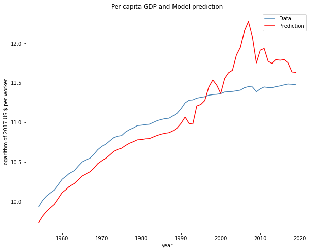

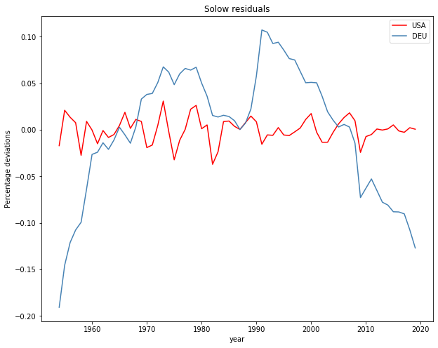

```
The correlation coefficient is:
 0.03450397929968406
Its p-value is:
 0.39164362657698726
```

```python
test = Solow_class('DEU', 2017) # country, year
test.get_data()
test.preliminary()
test.compute_parameters()
test.tfp_regression()
test.compare_data()
test.compare_usa()
```

### Comparison for JPN

```
                            OLS Regression Results
==============================================================================
Dep. Variable:                 rtfpna   R-squared:                       0.794
Model:                            OLS   Adj. R-squared:                  0.791
Method:                 Least Squares   F-statistic:                     246.9
Date:                Wed, 08 Mar 2023   Prob (F-statistic):           1.20e-23
Time:                        13:24:06   Log-Likelihood:                 59.280
No. Observations:                  66   AIC:                            -114.6
Df Residuals:                      64   BIC:                            -110.2
Df Model:                           1
Covariance Type:            nonrobust
==============================================================================
                 coef    std err          t      P>|t|      [0.025      0.975]
------------------------------------------------------------------------------
const         -0.5458      0.024    -22.403      0.000      -0.594      -0.497
x1             0.0102      0.001     15.714      0.000       0.009       0.011
==============================================================================
Omnibus:                        4.939   Durbin-Watson:                   0.034
Prob(Omnibus):                  0.085   Jarque-Bera (JB):                4.790
Skew:                          -0.610   Prob(JB):                       0.0912
Kurtosis:                       2.499   Cond. No.                         74.5
==============================================================================

Notes:
[1] Standard Errors assume that the covariance matrix of the errors is correctly specified.
```

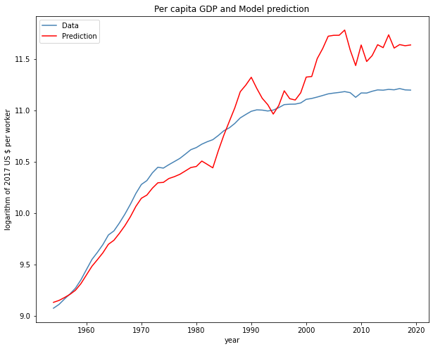

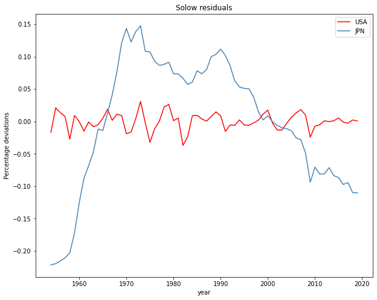

```
The correlation coefficient is:
 0.03568772315341062
Its p-value is:
 0.3880214724278836
```

```python
test = Solow_class('JPN', 2017) # country, year
test.get_data()
test.preliminary()
test.tfp_regression()
test.compute_parameters()
test.compare_data()
test.compare_usa()
```